# Practical Machine Learning - Analysis of HAR (Human Activity Recognition) Data Set

# Summary

It is now possible with many devices currently available on the market to log data on personal activities. People often record the quantity of the activies they perform but don't generally record the “quality” of those activities. This is an analysis of the HAR (Human Activity Recognition) data set to create a prediction model to predict the manner in which the participant performed the exercises for a testing dataset.

# Data Processing/Exploration

Two data sets were loaded from the HAR URL (https://d396qusza40orc.cloudfront.net/predmachlearn/): the first is a training set of 19622 entries of 160 features and the second is the test set of 20 entries with 160 features.

The majority of of the columns contain missing (NA) values. These columns were removed from the data set as they can provide no meaningful information towards the analysis. Further, the first 7 columns of each data set contains data that does not contribute to the analysis (e.g. “X”, user_name", “raw_timestamp_part_1”, “raw_timestamp_part_2”, “cvtd_timestamp”, “new_window”, “num_window”) so these were also removed.

```r
library(corrplot)
library(caret)
#Read training and test data sets
PMLtrainingALL<-read.csv("pml-training.csv", na.strings=c("NA",""))
PMLtestingALL<-read.csv("pml-testing.csv", na.strings=c("NA",""))

NAvalues <- apply(PMLtrainingALL, 2, function(x) { sum(is.na(x))})
PMLtraining<-PMLtrainingALL[,which(NAvalues==0)]
PMLtraining<- PMLtraining[,-(1:7)]

NAvalues <- apply(PMLtestingALL, 2, function(x) { sum(is.na(x))})
PMLtesting<-PMLtestingALL[,which(NAvalues==0)]
PMLtesting<- PMLtesting[,-(1:7)]
```

The summary of the “classe” variable (the variable we will be predicting) shows:

```r
summary(PMLtraining$classe)
```

```
##    A    B    C    D    E
## 5580 3797 3422 3216 3607
```

Initially, the correlations between features were checked to determine if there were any strong correlations between variables.

```r
CorrMtrx<- abs(cor(PMLtraining[,-53]))
diag(CorrMtrx) <- 0
which(CorrMtrx > 0.95, arr.ind=T)
```

```
##                  row col
## total_accel_belt   4   1
## accel_belt_z      10   1
## accel_belt_x       8   2
## roll_belt          1   4
## accel_belt_z      10   4
## pitch_belt         2   8
## roll_belt          1  10
## total_accel_belt   4  10
## gyros_dumbbell_z  33  31
## gyros_dumbbell_x  31  33
```

A plot of the correlations between the remaining factors visually shows those features with darker colors indicating strong correlations.

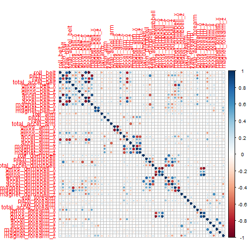

```r
corrplot(cor(PMLtraining[,-53]))
```

# Model Creation with Pre-processing (PCA)

Given the strong correlation between several of the features, preprocessing on the data set was performed to whittle down the relevant variables for analysis. The training data is subset into a training and test set in order to create and test.

```r
inTrain <- createDataPartition(y=PMLtraining$classe, p=.7, list=FALSE)
PMLtraining_train <- PMLtraining[inTrain,]
PMLtraining_test <- PMLtraining[-inTrain,]
```

```r
preProc <- preProcess(PMLtraining[,-53], method="pca", thresh = 0.98)
trainPCA <- predict(preProc, PMLtraining_train[,-53])
trainPCvalidate<-predict(preProc, PMLtraining_test[,-53])

modelFit<-train(PMLtraining_train$classe ~ . , method = "rf", data=trainPCA, trControl=trainControl(method = "cv", number = 4), importance=TRUE)
```

```r
PCApredVal <- predict(modelFit, trainPCvalidate)
confusionMatrix(PMLtraining_test$classe, PCApredVal)
```

```
## Confusion Matrix and Statistics
##
##           Reference
## Prediction    A    B    C    D    E
##          A 1662    4    4    4    0
##          B   22 1101   14    1    1
##          C    1    7 1004   13    1
##          D    2    0   47  913    2
##          E    0    5    6    8 1063
##
## Overall Statistics
##
##                Accuracy : 0.976
##                  95% CI : (0.972, 0.98)
##     No Information Rate : 0.287
##     P-Value [Acc > NIR] : <2e-16
##
##                   Kappa : 0.969
##  Mcnemar's Test P-Value : NA
##
## Statistics by Class:
##
##                      Class: A Class: B Class: C Class: D Class: E
## Sensitivity             0.985    0.986    0.934    0.972    0.996
## Specificity             0.997    0.992    0.995    0.990    0.996
## Pos Pred Value          0.993    0.967    0.979    0.947    0.982
## Neg Pred Value          0.994    0.997    0.985    0.995    0.999
## Prevalence              0.287    0.190    0.183    0.160    0.181
## Detection Rate          0.282    0.187    0.171    0.155    0.181
## Detection Prevalence    0.284    0.194    0.174    0.164    0.184
## Balanced Accuracy       0.991    0.989    0.965    0.981    0.996
```

# Model Creation without Pre-processing

Another model was created using the Random Forest methodology without PCA preprocessing to determine the accuracy that could be derived.

```r
modFitRF <- randomForest(classe ~. , data = PMLtraining_train, ntree=500)
RFPredict<-predict(modFitRF, PMLtraining_test)
confusionMatrix(RFPredict, PMLtraining_test$classe)
```

```
## Confusion Matrix and Statistics
##
##           Reference
## Prediction    A    B    C    D    E
##          A 1671    7    0    0    0
##          B    3 1131    4    0    0
##          C    0    1 1019    7    0
##          D    0    0    3  956   12
##          E    0    0    0    1 1070
##
## Overall Statistics
##
##                Accuracy : 0.994
##                  95% CI : (0.991, 0.995)
##     No Information Rate : 0.284
##     P-Value [Acc > NIR] : <2e-16
##
##                   Kappa : 0.992
##  Mcnemar's Test P-Value : NA
##
## Statistics by Class:
##
##                      Class: A Class: B Class: C Class: D Class: E
## Sensitivity             0.998    0.993    0.993    0.992    0.989
## Specificity             0.998    0.999    0.998    0.997    1.000
## Pos Pred Value          0.996    0.994    0.992    0.985    0.999
## Neg Pred Value          0.999    0.998    0.999    0.998    0.998
## Prevalence              0.284    0.194    0.174    0.164    0.184
## Detection Rate          0.284    0.192    0.173    0.162    0.182
## Detection Prevalence    0.285    0.193    0.175    0.165    0.182
## Balanced Accuracy       0.998    0.996    0.996    0.994    0.994
```

Given the greater accuracy of the RF model sans PCA, this was the model leveraged to perform the final test.

# Results

The final prediction achieved 100% accuracy of the 20 test records.

```r
RFFinalPrediction <-predict(modFitRF, PMLtesting)
RFFinalPrediction
```

```
##  1  2  3  4  5  6  7  8  9 10 11 12 13 14 15 16 17 18 19 20
##  B  A  B  A  A  E  D  B  A  A  B  C  B  A  E  E  A  B  B  B
## Levels: A B C D E
```